# How life expectancy change over time for each continent?

Claudio Desideri

Life expectancy for a country is the mean length of life over people of a country. Using variables life expectancy and population of a country:

1. derive a formula to compute life expectancy of a continent (a group of countries)
2. plot how life expectancy changed over time for each continent
3. do the same for the whole planet

# Loading libraries and gapminder dataset

Let’s load the relevant libraries.

```r
library("gapminder")
library(tidyverse)
```

# Computing life expectancy

We’re going to perform some inspections on the dataset in order to understand how to build a model. First let’s calculate for every year the expected life expectancy per continent using a weighted average.

```r
per_continents = gapminder |> group_by(year, continent) |> summarise( life_exp = sum(lifeExp * pop) / sum(pop), pop = sum(pop), .groups = "drop")
```

The formula used to calculate the life expectancy is:

$$\text{lifeExp}_{c,t} = \frac{\sum_{i \in c} \text{lifeExp}_{i,t} \cdot
\text{pop}_{i,t}}{\sum_{i \in c} \text{pop}_{i,t}}$$
In short it’s the mean of the life expectancy of every country weighted by the population, because every citized count as 1.

Now let’s plot the data.

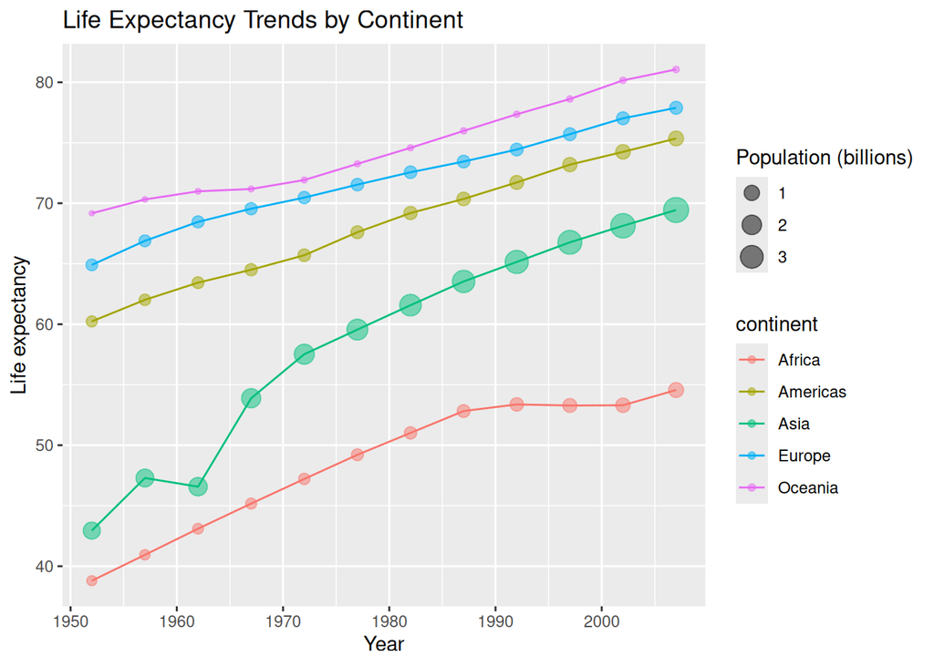

```r
per_continents |>
  ggplot(aes(x = year, y = life_exp, color = continent)) +
  geom_line() +
  geom_point(aes(size = pop/10^9), alpha = 0.5) +
  labs(title = "Life Expectancy Trends by Continent",
       x = "Year",
       y = "Life expectancy",
       size = "Population (billions)")
```

As we can see we have intuitively found out that every continent follows a more less straight line, with the exception of Asia in the late ’50s, early ’60s and Africa, that basically stops growing in the ’90s. Also asia has experienced a great growth in absolute population.

# The whole planet

Let’s craft the data for the whole planet, grouping by year, with the same weighted average used for continents.

```r
whole_planet = per_continents |> group_by(year) |> summarise(life_exp = sum(life_exp * pop) / sum(pop), pop = sum(pop))
```

Now let’s plot it to show it graphically.

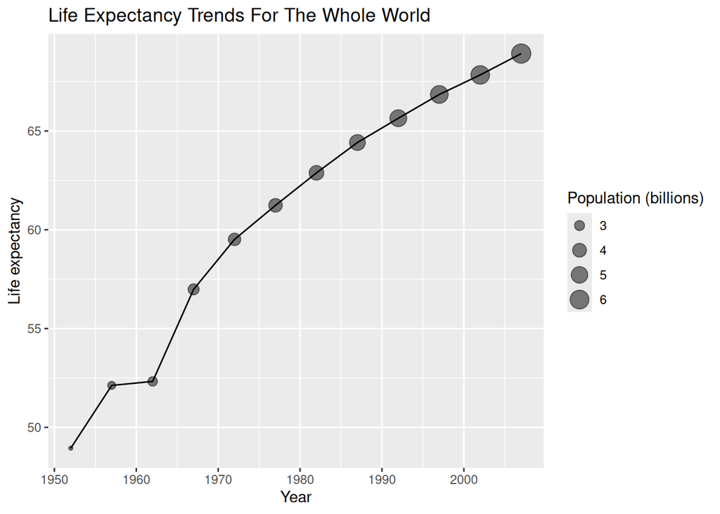

```r
whole_planet |> ggplot(aes(x = year, y = life_exp))+
  geom_line() +
  geom_point(aes(size = pop/10^9), alpha = 0.5) +
  labs(
    title = "Life Expectancy Trends For The Whole World",
    x = "Year",
    y = "Life expectancy",
    size = "Population (billions)"
  )
```

We can clearly see that the life expectancy is heavily influenced by the asian trend between ’50s and ’60s, due to Asia having a bigger population than any other continent. Apart from that, the trend has been increasing with time, with the african plateau not heavily influencing the whole world trend after the 90s.